# Nonlinear models part 4: Dose response curves

Nick Green, Kennesaw State University

November 23, 2021

# 1 Overview

This is one of several sections exploring some common nonlinear models and their applications. For most of these applications we will work through two examples. First, an analysis of simulated data, and second, an analysis of a real dataset. Simulating a dataset suitable for an analysis is an excellent way to learn about the analysis method, because it helps you see the relationship between the data-generating process and the analysis.

Another curve often faced by biologists is the dose response curve. As the name suggests, a dose response curve is one that describes the change in a biological system following a quantitative perturbation. The name “dose” comes from the fact that these kinds of models are common in medicine, physiology, and toxicology. However, dose response curves are potentially useful in many areas of biology.

# 2 Dose response curves

A **dose response curve** describes the change in a biological system following a quantitative perturbation. Most dose response models are nonlinear because of the dynamics of the systems they describe. Mechanistically, there is often a rate that scales with the current concentration of a compound, or some other aspect of the system. In other words, the dynamics of the system are described by a kind of **differential equation**. The state of the system is thus described by solutions to those equations.

There are many dose-response models out there. We will fit two common ones using the R package `drc` (Ritz et al. 2015). Many dose response models could also be fit by `nls()`, but we will use the `drc` package because of its convenience and so that we can learn an alternative approach.

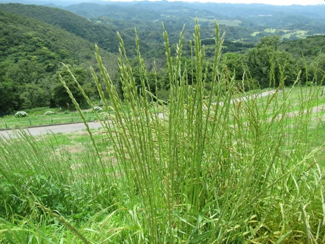

Perennial ryegrass (*Lolium perenne*)[^1].

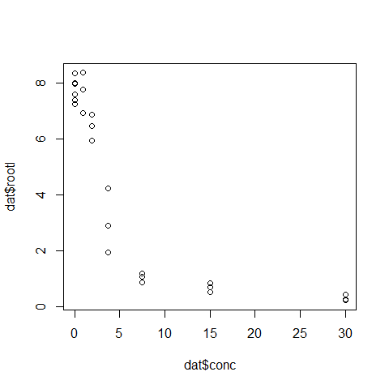

```r
library(drc)
dat <- ryegrass
plot(dat$conc, dat$rootl)
```

The plot suggests that increasing ferulic acid concentration decreases mean root length. The relationship also appears nonlinear: root length decreases very quickly at low ferulic acid concentration, and then levels out as concentration increases beyond about 5 mM.

We will try two nonlinear models found in the `drc` package. The first is the **log-logistic model**. The log-logistic model comes in several flavors, defined by the number of parameters used to specify the curve. Two common varieties are shown below. By convention, one of the parameters is labeled “*e*”, but it is not the same as Euler’s constant *e* ($\approx$ 2.71828). The parameter labeled *e* shows up only in the exponent as $log(e)$, but this does not mean $log(exp(1))$ (which would be 1, by definition). The bases of the exponents in the models below are Euler’s *e*. For clarity, the parameter *e* is sometimes labeled with another letter, or the exponential function $e^x$ is written as $exp(x)$.

**Three-parameter log-logistic:**

$$f\left(x,\left(b,d,e\right)\right)=\frac{d}{1+e^{b\left(log{\left(x\right)}-log{\left(e\right)}\right)}}=\frac{d}{1+exp\left(log{\left(x\right)}-log{\left(e\right)}\right)}$$

**Four-parameter log-logistic:**

$$f\left(x,\left(b,c,d,e\right)\right)=\frac{d-c}{1+e^{b\left(log{\left(x\right)}-log{\left(e\right)}\right)}}=\frac{d-c}{1+exp\left(b\left(log{\left(x\right)}-log{\left(e\right)}\right)\right)}$$

Just for fun we can also try a **Weibull type I** function:
$$\begin{matrix}f\left(x,\ \left(b,c,d,e\right)\right)=&c+\left(d-c\right)e^{-e^{b\left(log{\left(x\right)}-log{\left(e\right)}\right)}}\\f\left(x,\ \left(b,c,d,e\right)\right)=&c+\left(d-c\right)exp\left(-exp\left(b\left(log{\left(x\right)}-log{\left(e\right)}\right)\right)\right)\\\end{matrix}$$

Fitting the models in `drc` is straightforward. First define the response and predictor variables in a formula (as in `lm()` and other functions), specify the dataset to be used, and finally the curve (`fct`) to be fitted. The full list of functions that `drm()` can fit can be found with the command `getMeanFunctions()`.

```r
mod1 <- drm(rootl~conc, data=ryegrass, fct=LL.3())
mod2 <- drm(rootl~conc, data=ryegrass, fct=LL.4())
mod3 <- drm(rootl~conc, data=ryegrass, fct=weibull1())

summary(mod1)
```

```
##
## Model fitted: Log-logistic (ED50 as parameter) with lower limit at 0 (3 parms)
##
## Parameter estimates:
##
##               Estimate Std. Error t-value   p-value
## b:(Intercept)  2.47033    0.34168  7.2299 4.011e-07 ***
## d:(Intercept)  7.85543    0.20438 38.4352 < 2.2e-16 ***
## e:(Intercept)  3.26336    0.19641 16.6154 1.474e-13 ***
## ---
## Signif. codes:  0 '***' 0.001 '**' 0.01 '*' 0.05 '.' 0.1 ' ' 1
##
## Residual standard error:
##
##  0.5615802 (21 degrees of freedom)
```

```r
summary(mod2)
```

```
##
## Model fitted: Log-logistic (ED50 as parameter) (4 parms)
##
## Parameter estimates:
##
##               Estimate Std. Error t-value   p-value
## b:(Intercept)  2.98222    0.46506  6.4125 2.960e-06 ***
## c:(Intercept)  0.48141    0.21219  2.2688   0.03451 *
## d:(Intercept)  7.79296    0.18857 41.3272 < 2.2e-16 ***
## e:(Intercept)  3.05795    0.18573 16.4644 4.268e-13 ***
## ---
## Signif. codes:  0 '***' 0.001 '**' 0.01 '*' 0.05 '.' 0.1 ' ' 1
##
## Residual standard error:
##
##  0.5196256 (20 degrees of freedom)
```

```r
summary(mod3)
```

```
##
## Model fitted: Weibull (type 1) (4 parms)
##
## Parameter estimates:
##
##               Estimate Std. Error t-value   p-value
## b:(Intercept)  2.39341    0.47832  5.0038 6.813e-05 ***
## c:(Intercept)  0.66045    0.18857  3.5023  0.002243 **
## d:(Intercept)  7.80586    0.20852 37.4348 < 2.2e-16 ***
## e:(Intercept)  3.60013    0.20311 17.7250 1.068e-13 ***
## ---
## Signif. codes:  0 '***' 0.001 '**' 0.01 '*' 0.05 '.' 0.1 ' ' 1
##
## Residual standard error:
##
##  0.5488238 (20 degrees of freedom)
```

All three models fit, had statistically-significant parameters, and had similar residual standard errors (RSE; a measure of model fit similar to RMSE). Model 2 (4 parameter log-logistic) had the smallest RSE and the smallest AIC:

```r
AIC(mod1, mod2, mod3)
```

```
##      df      AIC
## mod1  4 45.20827
## mod2  5 42.31029
## mod3  5 44.93439
```

This is moderately convincing evidence that model 2 is the best-fitting of the three models that we fit. Let’s calculate predictions and 95% CI for a range of concentrations and present them in a graph. Unlike `nls()` objects, models fitted using `drm()` have a predict method that can generate confidence intervals. The code below may return warnings, but these messages can probably be ignored.

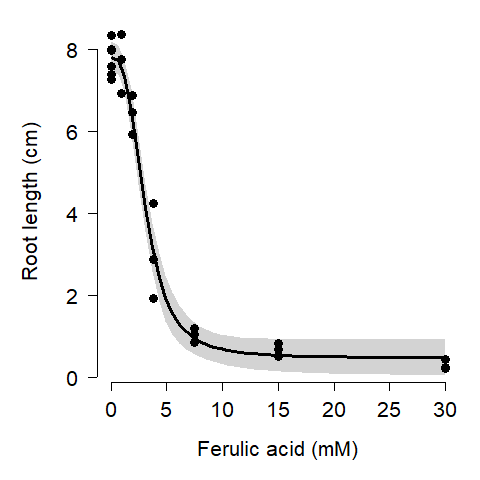

```r
L <- 50
px <- seq(min(dat$conc), max(dat$conc), length=L)
pred <- predict(mod2,
                newdata=data.frame(conc=px),
                interval="confidence")
mn <- pred[,1]
lo <- pred[,2]
up <- pred[,3]

# fancy plot options
par(mfrow=c(1,1), mar=c(5.1, 5.1, 1.1, 1.1),
    las=1, lend=1, bty="n",
    cex.axis=1.3, cex.lab=1.3)

# make the plot
plot(dat$conc, dat$rootl,
     pch=16, cex=1.2,
     xlab="Ferulic acid (mM)",
     ylab="Root length (cm)")
polygon(c(px, rev(px)), c(lo, rev(up)),
        border=NA, col="lightgrey")
points(px, mn, type="l", lwd=3)
points(dat$conc, dat$rootl, pch=16, cex=1.2)
```

Regardless of whether or not you get warning messages, you should carefully inspect the data, the residuals, and the model predictions to be sure that the estimates are biologically reasonable. The figure above shows no obvious red flags, but your data might not be so well-behaved.

[**Go back to main page**](https://greenquanteco.github.io/index.html)

# 3 References

Inderjit, J. C. Streibig, and M. Olofsdotter. 2002. [Joint action of phenolic acid mixtures and its significance in allelopathy research](https://doi.org/10.1034/j.1399-3054.2002.1140312.x). Physiologia Plantarum 114:422–428.

Ritz, C., F. Baty, J. C. Streibig, and D. Gerhard. 2015. [Dose-response analysis using R](https://doi.org/10.1371/journal.pone.0146021). PLoS ONE 10:e0146021.

# 4 Legal notice

This site is for educational purposes only. This work and its content is released under the [Creative Commons Attribution-ShareAlike 4.0](https://creativecommons.org/licenses/by-sa/4.0/) license. Inclusion of third-party data falls under guidelines of fair use as defined in [section 107 of the US Copyright Act of 1976](https://www.law.cornell.edu/uscode/text/17/107).

[^1]: Photo: [flower-db.com](https://www.flower-db.com/en/flowers/lolium-perenne) (accessed 2021-09-24)